# another experiment

Evangeline Reynolds

2024-11-05

## Proposal:

Everyday ggplot2 extension: New approaches to light-weight ‘geom’ extension

Creating new layers (geom_* functions) in ggplot2 extension has been described as an ‘involved process’. While new educational material has lowered the conceptual barrier to entry, the amount of scaffolding code required for classical extension can make regularly using extension feel prohibitive. In this talk, I’ll discuss strategies and tools to make experimentation with new functionality more light-weight and fun. A few practical applications in statistics pedagogy will be presented.

## Intro Thoughts

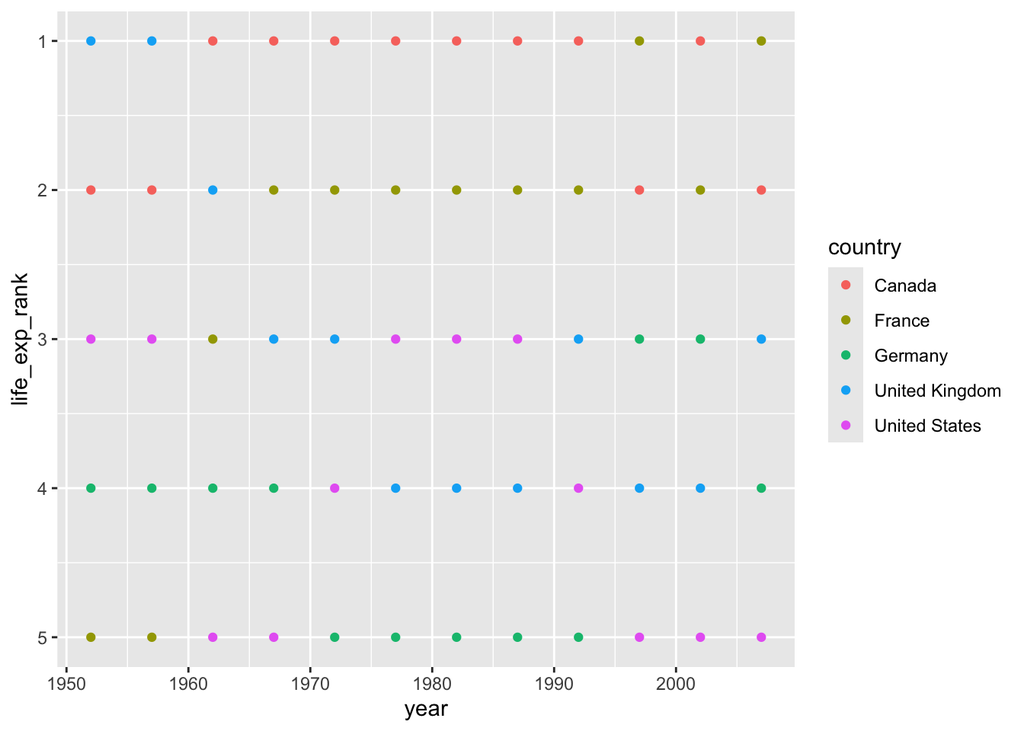

```r
library(tidyverse)
library(ggbump)

life_exp_rank_2020 %>%
  ggplot() +
  aes(x = year,
      y = life_exp_rank,
      color = country) +
  geom_point() +
  scale_y_reverse()
```

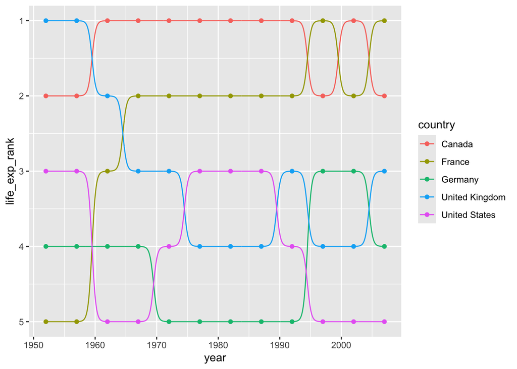

```r
last_plot() +
  geom_bump()
```

# Graphical Poem!!!

–

“The article concludes by discussing some perceptual issues, and thinking about how we can build on the grammar to learn how to create graphical ‘poems.’”

```r
life_exp_rank_2020 %>%
  ggplot() +
  aes(x = year,
      y = life_exp_rank,
      color = country) +
  scale_y_reverse() +
  geom_point() +
  geom_bump()
```

[output not shown]

- ‘I have two kids, it’s so hard to be so deep in ggplot, it takes at least two days just to get all the information in your head again. So I’m struggling with maintaining [ggbump, ggaluvial, ggsankey]’
- ‘I have about 200 kids…’
- ‘I have 1000 kids…’
- ‘I have a thesis to finish’

‘How to extend ggplot2 while drowning’…

–

‘How to keep house while drowning’…

[figure not shown]

‘How to extend ggplot2 while drowning’…

Don’t go deep.

–

Stay in the shallow end.

Caveat… mostly interested in Stat extension. Powerful and underutilized for data exploration and statistical education.

–

… creating new Stats is one of the most useful ways to extend the capabilities of ggplot2.’ – ggplot2: Elegant Graphics for Data Analysis

# Classical Stat creation…

`geom_support()`

What are the logical limits for observed proportions?

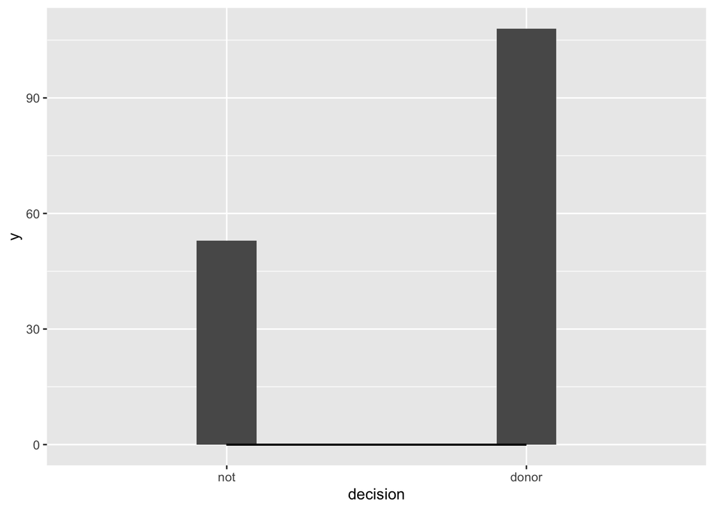

# Step 0. use base ggplot2, compute before plotting

```r
isi_donor_url <- "https://www.isi-stats.com/isi/data/prelim/OrganDonor.txt"

donor <- read_delim(isi_donor_url) %>%
  mutate(decision = fct_rev(Choice))
```

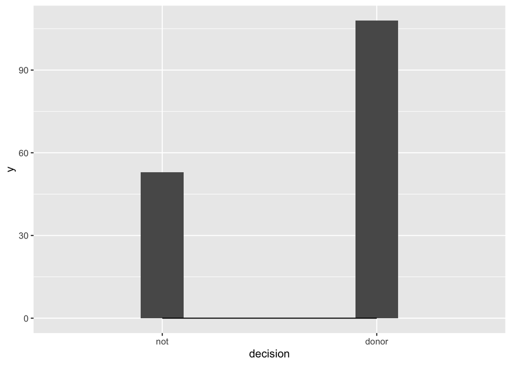

```r
donor |>
  summarise(x = min(as.numeric(decision)),
            xend = max(as.numeric(decision)),
            y = 0,
            yend = 0) ->
donor_min_max

donor |>
ggplot() +
  aes(x = decision) +
  geom_bar(width = .2) +
  geom_segment(data = donor_min_max,
               aes(x = x,
                   xend = xend,
                   y = 0,
                   yend = 0))
```

# Step 1.

```r
compute_panel_support <- function(data, scales){

  data |>
    summarize(xend = max(x),
              x = min(x),
              yend = 0,
              y = 0)

}
```

# Step 2.

```r
StatSupport <- ggproto(`_class` = "StatSupport",
                       `_inherit` = ggplot2::Stat,
                       compute_panel = compute_panel_support,
                       required_aes = "x")
```

# Step 3.

```r
geom_support <- function (mapping = NULL, data = NULL,
                          geom = "segment", position = "identity",
                          ..., show.legend = NA, inherit.aes = TRUE)
{
    layer(data = data, mapping = mapping, stat = StatSupport,
        geom = geom, position = position, show.legend = show.legend,
        inherit.aes = inherit.aes, params = rlang::list2(na.rm = FALSE,
            ...))
}
```

# Yippee!! Nice poem!!

```r
donor |>
  ggplot() +
  aes(x = decision) +
  geom_bar(width = .2) +
  geom_support()
```

[output not shown]

# At what cost?

700 characters!?

only 20 percent defines new compute of interest!?

```
## [1] 158
```

```
## [1] 614
```

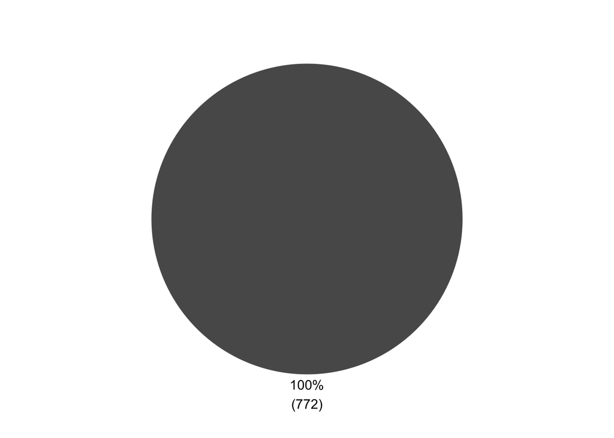

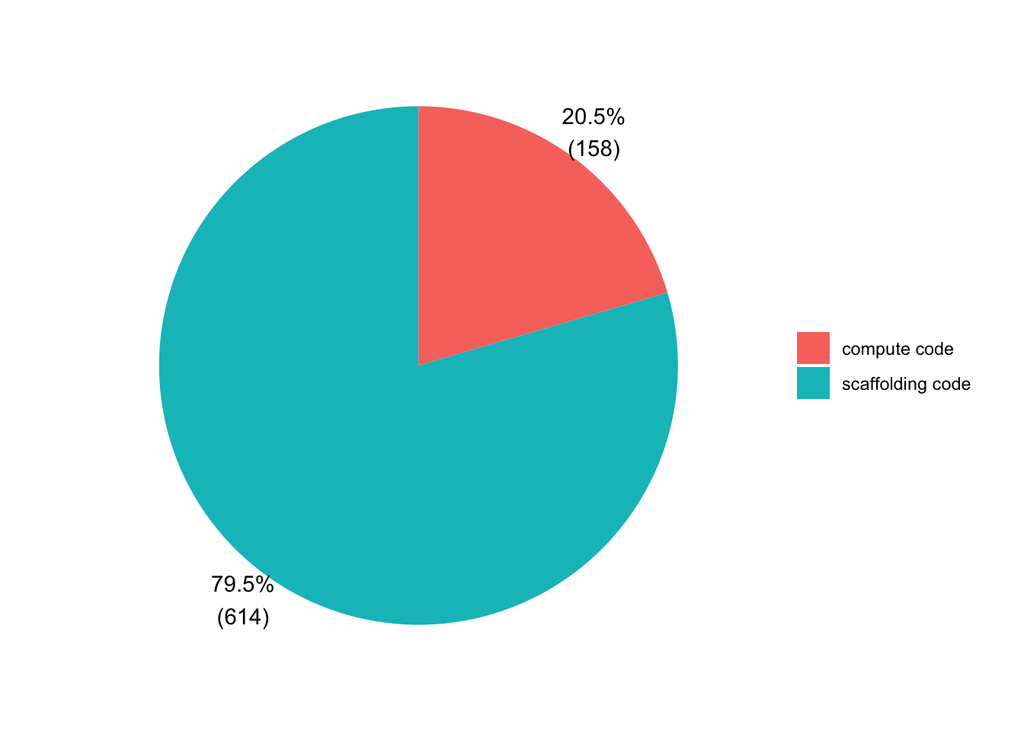

[output not shown]

# New approach, w {statexpress}

# Step 1. Compute

```r
compute_panel_support <- function(data, scales){

  data |>
    summarize(xend = max(x),
              x = min(x),
              yend = 0,
              y = 0)

}
```

# Step 1.5 Sketch

```r
library(statexpress)

donor |>
  ggplot() +
  aes(x = decision) +
  geom_bar(width = .2) +
  # sketching geom_support
  qlayer(stat = qstat_panel(compute_panel_support),
         geom = GeomSegment)
```

[output not shown]

statexpress::qstat_panel - define panel-wise computation for a temp stat. statexpress::qlayer - use a more filled-in version of layer

# Step 2. User-facing function

```r
geom_support <- function(...){

  qlayer(stat = qstat_panel(compute_panel_support),
         geom = GeomSegment, ...)

}
```

# Yippee - Graphical Poem!!

```r
donor |>
  ggplot() +
  aes(x = decision) +
  geom_bar(width = .2) +
  geom_support()
```

[output not shown]